# [DDREF](http://rpubs.com/benjaminhaley/ddref)

Measure ddref, for my thesis.  
benjamin.haley@gmail.com  
*last update: April 2014*

# Abstract

# Table of contents

- Background
  - Defining DDREF - What is the equation?
  - Log Likelihood - How is log likelihood calculated?
  - Metaregression - Show the principals of metaregression.
- Data
  - Data Funnel - Which data will we analyze?
  - Data Cleaning - Damn, data, you look good!
  - Concordance - Tables describing the data in detail.
  - Visualize - Show what the data looks like.
  - Atomic Bomb Survivors - Load data from atomic bomb survivors as well.
- Analysis
  - Reproduce BEIR 10B2 - Show that we can fit the same model of cancer risk vs. dose as BEIR VII.
  - Reproduce BEIR 10B3 - Show that we can fit the same model of lifespan vs. dose as BEIR VII.
  - Reproduce BEIR 10B4 - Show that we can reproduce the likelihood profiles from BEIR VII.
  - 10B3 on all data - Fit 1/lifespan models on all of the data.
  - 10B4 on all data - 1/lifespan models profile likelihoods on all of the data.
  - 10B3 with metaregression - Reproduce dose response figure applying the principals of meta-regression
  - 10B4 with metaregression - Reproduce profile likelihood figure applying the principals of meta-regression.
  - 10B3 metareression on all data Apply meta regression to all of the datasets.
  - 10B4 metareression on all data Apply meta regression to all of the datasets to generate profiles.

# Defining DDREF

*Last update: April 2013*

##### What is DDREF?

DDREF is defined ambiguosly. It can be derived from acute exposures as 1 + Dβ/α where response ~ D*α + D*β<sup>2.</sup> But for the purposes of radiation protection, we need a functional definition, that distinguishes a cutoff of dose and doserate beyond which the DDREF correction ought to be used. What are these cutoffs? I will do a literature search to find out.

#### Notes

*ICRP 2007 3.2.1 (70-73)*  
DDREF is 2 based on LLS dose response curves, 'experimental data', and 'probabilistic uncerainty analysis' conducted by others (NCRP, 1997, EPA, 1999, NCI/CDC, 2003, Annex A).

*ICRP 2007 A.3.1 (A 62)*  
When dose rates are lower than around 0.1 Gy/hour there is repair of cellular radiation injury during the irradiation. This causes the b component to decrease and to reach zero at very low dose rates. The a component is not modiﬁable by changing dose rate.

*BEIR VII Chapter 2*

- How B decreases with dose rate (Edwards and others 1989)
- Estimate DDREF from animal data (Tucker and others 1998)
- More DDREF from animals data (Lorenz and others 1994)
- More DDREF in animals studies (Ullrich and Storer 1979a; Ullrich and others 1987)

*BEIR VII Chapter 10*  
DREF is the term for dose rate reduction, as opposed to both dose and dose rate reduction

- pg 246 claims that up to 24 hours seems to be required for full repair from a single dose
- pg 248 Says LSS DDREF are roughly equivilant to UNSCEAR DDREF estimated at 1 Sv of exposure.
- pg 250 used a cutoff of 1.5 - 2 Gy for animal data to avoid leveling off effects!!!!!!
- pg 254 when fractionated, dose response can be described as a*D + B*(D<sup>2/K)</sup> where K is the number of fractions
- pg 255 they were forced to use mean survival times, instead of lifespan, because they did not have individual level data! They admit this is problematic, something I can address!
- pg 255 importantly they ignore data that does not account for competing sources of risk. I do not know if I can do this! But perhaps this is rather irrelevant in the case of lifespan most of these studies
- pg 255 They only used the accute exposures from Edwards (1992) excluding tables 1 and 2

#### References

- Edwards 1989, Chromosome aberrations in human lymphocytes
- Edwards 1992, Low Dose and Low Dose Rate Effects in Laboratory Animals
- Lorenz 1994, Dose and dose-rate dependence of the frequency of hprt deficient T lymphocytes in the spleen of the 137Cs gamma-irradiated mouse
- Tucker 1998, The accumulation of chromosome aberrations and Dlb-1 mutations in mice with highly fractionated exposure to gamma radiation
- Ullrich 1979a, Influence of gamma irradiation on the development of neoplastic disease in mice. I. Reticular tissue tumors
- Ullrich 1987, Myeloid leukemia in male RFM mice following irradiation with fission spectrum neutrons or gamma rays.

#### Conclusions

1. Survival hazard was not used in BEIR VII, only mean lifespan.
2. BEIR VII used 1.5 Sv as an upper threshold, because response falls off above this level, I should too.
3. When doses are fractionated apply the equation: `a*D + B*(D^2/K)`, where K is the number of fractions
4. Dealing with doserate changes is hard, pg 246 suggests that repair processes take up to 24 hours, so this might be a natural break point.
5. Estimate DDREF at 1 Sv to make it compatible with lss estimates

^ back to table of contents

# Log likelihood

I need to know how log likelihood is calculated. Basically it should be proportional to

sum((actual - predicted)<sup>2</sup> / variance)

And variance is measured as

If variance is estimated at zero, this goes to infinity, so the overfit regression model has problems.

```r
data <- data.frame(y = 1:100, x = rnorm(100, 1:100))
n <- nrow(data)
m <- glm(y ~ x, data = data)
data$p <- predict(m)
data$e <- data$y - data$p
o2 = with(data, sum(e^2)/(n))
o2
```

```
## [1] 0.8835
```

```r
l <- with(data, -(n/2) * log(2 * pi) + -(n/2) * log(o2) + -(1/(2 * o2)) * sum(e^2))
l - as.numeric(logLik(m))
```

```
## [1] 0
```

^ back to table of contents

# DATA: Data Funnel

*Last update: April 2013*

### Introduction:

Create a data set that might be used for DDREF analysis and make a description of this data.

```r
# LIBRARIES
library(plyr)
library(dplyr)
library(ggplot2)
library(survival)

# DATA
setwd("~/janus")
d <- readRDS("data/external5.rds")

# HELPERS Make survival data amenable to ggplot
table0 <- function(...) table(..., useNA = "ifany")

# Report for funnel graph
count <- function(data) {
    count_unique <- function(x) length(unique(x))
    with(data, c(studies = count_unique(file), clusters = count_unique(cluster),
        treatments = count_unique(group_id), animals = count_unique(id), `not vetted` = count_unique(id) -
            count_unique(id[is_vetted]), `to exclude` = count_unique(id[exclude])))
}

filter_by_n_groups <- function(data, threshold = 3) {
    ddply(data, .(cluster), function(df) {
        n_groups = length(unique(paste(df$dose, df$dose_rate, df$fractions)))
        if (n_groups >= threshold) {
            return(df)
        } else {
            return(NULL)
        }
    })
}

# Define
bad_qualities <- c("accel. alpha local", "accel. alpha whole body", "accel. neutrons 0.1-10 MeV",
    "neutrons 1-10 MeV", "neutrons C-252", "neutrons fission", "neutrons>10 MeV",
    "X-rays local", "gamma-rays local", "Bremsstrahlung > 3MeV.")

# Aliases Allow a more concise representation of a name.  For instace ♂ is
# preferable to Male
aliases <- list(quality = c(`gamma-rays Co-60` = "γ-ray", `gamma-rays Co-60, gamma-rays Co-60` = "γ-ray",
    `gamma-rays Co-60, gamma-rays Co-60, gamma-rays Co-60` = "γ-ray", `gamma-rays Cs-137` = "γ-ray",
    `gamma-rays whole body` = "γ-ray", `gamma-rays` = "γ-ray", `X-rays whole body` = "X-ray"),
    sex = c(Both = "♂/♀", Female = "♀", Male = "♂"), lab = c(`2` = "CEN-FAR",
        `3` = "ENEA", `9` = "SCK/CEN", `11` = "TNO", `1002` = "DAVIS", `1003` = "ANL",
        `1005` = "ITRI", `1007` = "ORNL", `1008` = "CSU"), strain = c(beagle = "Beagle"))


threshold_dose <- 1.5

# Fix TODO(later) move these fixes to radiation.R

# Stray fixes Some of the B6CF1 mice are missing their species
d[d$strain == "B6CF1", "species"] <- "Mouse"
## One animal is listed as a control despite having a dose, remove her
contradictory_dose_and_quality <- (d$quality == "none (controls)" & d$dose !=
    0 & !is.na(d$dose) & !is.na(d$quality))
d <- d[!contradictory_dose_and_quality, ]

# NA doses
d$dose[is.na(d$dose)] <- 0
d$dose_rate[is.na(d$dose_rate)] <- 0
d$fractions[d$dose == 0] <- 0
d$dose_rate[d$dose == 0] <- 0

# NA quality
d$quality[is.na(d$quality)] <- "none (controls)"

# Add missing fractions
d$fractions[is.na(d$fractions)] <- 1
d$fractions[d$fractions == 0] <- 1

# Add fractions seperated by days
d$day_fractions <- d$fractions
s <- d$fraction_interval < 1 & !is.na(d$fraction_interval)
d$day_fractions[s] <- d$fractions[s] * d$fraction_interval[s]

# Add lab
d$lab <- sub("(^[0-9]*).*$", "\\1", d$study_id)

# If assignment age is not listed, assume it is zero
d$assignment_age[is.na(d$assignment_age)] <- 0

# If an animal is a control, it should have no age at treatment Nor an age
# at last treatment
d$age_at_treatment[d$dose == 0] <- NA
d$age_at_last_treatment[d$dose == 0] <- NA

# Age at last treatment
d$age_at_last_treatment <- d$age_at_treatment
s <- !is.na(d$fraction_interval)
d$age_at_last_treatment[s] <- with(d[s, ], age_at_treatment + fraction_interval *
    (fractions - 1), )

# Assign aliases Replace all values in a given column with their aliases
# e.g. replace gamma-rays with γ
for (column in names(aliases)) {
    for (name in names(aliases[[column]])) {
        alias = aliases[[column]][name]
        d[d[column] == name & !is.na(d[column]), column] <- alias
    }
}
```

#### Define Clusters

In general we want to cluster on:

`lab, species, strain, and sex`

```r
d$cluster = with(d, paste(sex, strain, species, lab, sep = "--"))
```

But also

```
`assignment_age and quality`
```

Which require special consideration.

##### Intended Assignment Age

Assignment age was usually recorded 'as intended'. So that all mice in a group have an assignment age of 56 days old. Such precision is dubious/impossible and most likely represents a reconstruction based on the methods described about the experiment.

By contrast, argonne data recorded true age at treatment assignment so that animals vary by up to 50 days within a single cluster. These animals should not be divided into seperate clusters, because they are all adults. By contrast animals irradiated at -4 days and 7 days old should be put into seperate age clusters because they represent very different stages of development.

The most complete way to handle this situation is do define a lifestage by age for each species and use this for clustering. But this approach is arbitrary, contrived, and needlessly complex.

Instead we will define a new feild, `approximate_assignment_age`. For most groups this will be the reported `assignment_age`. For argonne groups we will define it by the median `assignment_age`.

```r
d$intended_assignment_age <- d$assignment_age
labs_that_recorded_true_age_at_assignment <- c("ANL")
clusters_that_recorded_true_age_at_assignment = unique(d$cluster[d$lab %in%
    labs_that_recorded_true_age_at_assignment])
for (c in clusters_that_recorded_true_age_at_assignment) {
    d$intended_assignment_age[d$cluster == c] <- median(d$assignment_age[d$cluster ==
        c])
}
d$cluster <- paste(d$cluster, d$intended_assignment_age, sep = "--")
```

##### Duplicate controls

Control animals may control for multiple clusters. For example the same mouse could control for a group exposed to gamma rays and others exposed to x-rays. Therefore control groups ought to be duplicated and included in each cluster that they might control for.

Concretely, control animals should match sex, species, strain, assignment age, and lab. Controls should be duplicated for each unique quality and age of first exposure provided the aforementioned criteria are met.

```r
d <- ddply(d, .(cluster), function(df) {
    control <- df[df$quality == "none (controls)", ]
    treatment <- df[df$quality != "none (controls)", ]

    # Create a cluster for each non control intended age of treatment
    ddply(treatment, .(quality), function(treatment_group) {

        # Add control to each treatment group
        df2 <- rbind(treatment_group, control)

        # Define quality by the treatment group i.e.  quality = 'none (control)'
        # -> quality = 'gamma'
        df2$quality <- treatment_group$quality[1]

        # Add quality to the cluster name
        df2$cluster <- with(df2, paste(cluster, quality, sep = "--"))
        df2
    })
})

# Label the duplicates
d$duplicates <- duplicated(d$id)

# Show that all of them recieved 0 dose
with(d, all(dose[duplicates] == 0))
```

```
## [1] TRUE
```

```r
# Count the number of duplicates
table(d$duplicates)  # 23657
```

```
##
##  FALSE   TRUE
## 116542  23657
```

```r
# FILTER

# Initial counts
count(d)
```

```
##    studies   clusters treatments    animals not vetted to exclude
##         24         82        827     116542      60118      15465
```

```r
# Only low-LET, whole body
d <- d[!d$quality %in% bad_qualities, ]
count(d)
```

```
##    studies   clusters treatments    animals not vetted to exclude
##         24         43        457      76096      23213      15465
```

```r
# Dose below threshold (as in BEIR VII)
d <- d[!(d$dose > threshold_dose), ]
count(d)
```

```
##    studies   clusters treatments    animals not vetted to exclude
##         23         35        230      45730       6220       9662
```

```r
# Lifespan not NA
d <- d[!is.na(d$lifespan), ]
count(d)
```

```
##    studies   clusters treatments    animals not vetted to exclude
##         23         35        230      45722       6220       9662
```

```r
# No other treatments
d <- d[d$other_treatments == "none", ]
count(d)
```

```
##    studies   clusters treatments    animals not vetted to exclude
##         21         34        175      43043       4832       8516
```

```r
# Died before their 'assignment age' TODO(later) why should there be any
# mice that died before their assignemtn age?
d <- d[d$lifespan > d$assignment_age, ]
count(d)
```

```
##    studies   clusters treatments    animals not vetted to exclude
##         21         34        175      42948       4797       8509
```

```r
# Remove those that should be excluded
exclusions <- sort(unique(d$reason))
exclusions <- exclusions[exclusions != ""]
for (ex in exclusions) {
    d <- d[!d$reason == ex, ]
    print(ex)
    print(count(d))
}
```

```
## [1] "see exclusion-1 in radiation.R"
##    studies   clusters treatments    animals not vetted to exclude
##         21         34        174      42941       4797       8502
## [1] "see exclusion-10 in radiation.R"
##    studies   clusters treatments    animals not vetted to exclude
##         21         33        142      40906       4797       6467
## [1] "see exclusion-11 in radiation.R"
##    studies   clusters treatments    animals not vetted to exclude
##         20         32        138      39803       4797       5364
## [1] "see exclusion-12 in radiation.R"
##    studies   clusters treatments    animals not vetted to exclude
##         20         32        137      39506       4797       5067
## [1] "see exclusion-13 in radiation.R"
##    studies   clusters treatments    animals not vetted to exclude
##         19         32        136      39440       4797       5001
## [1] "see exclusion-5 in radiation.R"
##    studies   clusters treatments    animals not vetted to exclude
##         18         31        133      39419       4797       4980
## [1] "see exclusion-7 in radiation.R"
##    studies   clusters treatments    animals not vetted to exclude
##         18         31        132      35706       4797       1267
## [1] "see exclusion-8 in radiation.R"
##    studies   clusters treatments    animals not vetted to exclude
##         17         31        129      34997       4797        558
## [1] "see exclusion-9 in radiation.R"
##    studies   clusters treatments    animals not vetted to exclude
##         16         27        119      34439       4797          0
```

```r
# Remove cases with few treatment groups
d <- filter_by_n_groups(d)
count(d)
```

```
##    studies   clusters treatments    animals not vetted to exclude
##          8         17         95      29072          0          0
```

```r
# studies clusters treatments animals not vetted to exclude 8 17 95 29072
# 0 0

# How many duplicates after filtering?
table0(d$duplicates)  # 19462 FALSE 9610 TRUE
```

```
##
## FALSE  TRUE
## 19462  9610
```

```r
# Warnings show, but do not remove
warnings <- sort(unique(d$warning_reason))
warnings <- warnings[warnings != ""]
d_wo_warnings <- d
for (w in warnings) {
    d_wo_warnings <- d_wo_warnings[!d_wo_warnings$warning_reason == w, ]
    print(w)
    print(count(d_wo_warnings))
}
```

```
## [1] "see warning-1 in radiation.R"
##    studies   clusters treatments    animals not vetted to exclude
##          7         15         83      20639          0          0
## [1] "see warning-2 in radiation.R"
##    studies   clusters treatments    animals not vetted to exclude
##          7         15         82      20209          0          0
## [1] "see warning-3 in radiation.R"
##    studies   clusters treatments    animals not vetted to exclude
##          7         15         80      19905          0          0
## [1] "see warning-4 in radiation.R"
##    studies   clusters treatments    animals not vetted to exclude
##          6         14         77      19658          0          0
## [1] "see warning-5 in radiation.R"
##    studies   clusters treatments    animals not vetted to exclude
##          6         14         76      19305          0          0
## [1] "see warning-6 in radiation.R"
##    studies   clusters treatments    animals not vetted to exclude
##          6         14         75      18995          0          0
```

```r
d_wo_warnings <- filter_by_n_groups(d_wo_warnings)
count(d_wo_warnings)
```

```
##    studies   clusters treatments    animals not vetted to exclude
##          6         13         73      18903          0          0
```

```r
# studies clusters treatments animals not vetted to exclude 6 13 73 18903
# 0 0

# Save
setwd("~/janus")
saveRDS(d, "data/funneled.rds")
```

^ back to table of contents

# Clean

DDREF data has been filtered. Now its time to prettify it.

```r
# Libraries
library(plyr)
library(dplyr)
library(ggplot2)
library(survival)

# Data
setwd("~/janus")
d <- readRDS("data/funneled.rds")

# Helpers
pluralize <- function(x) {
    c(Mouse = "Mice", Rat = "Rats", Dog = "Dogs", Peromyscus = "Peromyscus")[x]
}

# Is acute?
d$acute <- d$fractions == 1 | d$dose == 0
d$protracted <- d$dose > 0 & (d$fractions > 1 | d$dose_rate < 0.01)

# Observations per cluster
d = d %.% group_by(cluster) %.% mutate(n_in_cluster = length(cluster))

# Give the clusters pretty names
for (c in unique(d$cluster)) {
    elements = as.list(strsplit(c, "--")[[1]])
    names(elements) <- c("sex", "strain", "species", "lab", "age", "quality")
    pretty_cluster = with(elements, paste(sex, strain, pluralize(species), lab,
        "\n", quality, "at", age, "days old"))
    d$cluster[d$cluster == c] <- pretty_cluster
}

# Define Acute
chronic <- d$fractions > 1
d$type <- "A"
d$type[chronic] <- "C"

# Order clusters By number of observations.  This will put the cluster
# with the most observations first in ggplots
sort_by_n <- function(x) {
    factor(x, levels = names(sort(table(x), decreasing = TRUE)))
}
d$cluster = sort_by_n(d$cluster)
d$cluster_id <- as.numeric(d$cluster)
d$cluster <- with(d, paste0(cluster_id, " - ", cluster))
d$cluster = sort_by_n(d$cluster)

# Save Data for later use
saveRDS(d, "data/ddref.rds")
write.csv(d, file = "data/ddref.csv")
```

### Results

Data is so fresh and so clean.

# Concordance

*Last update: April 2013*

Give a detailed description of the dataset for those that want to make a close inspection.

```r
# Libraries
library(plyr)
library(dplyr)
library(ggplot2)
library(survival)

# Data
setwd('~/janus')
d <- readRDS('data/ddref.rds')

# Helpers
group_summary <- function(data){
    .all <- function(x, c=' ') paste(unique(x), collapse=c)
    summary <- with(data, c(
        ' ♂ '          = sum(sex == '♂'),
        ' ♀ '          = sum(sex == '♀'),
        'avg. age'      = round(mean(lifespan)),
        'dose'          = .all(signif(dose, 2)),
        'rate'          = .all(signif(dose_rate, 1)),
        '# fractions'   = .all(fractions),
        warnings        = .all(gsub('[^0-9]', '', warning_reason))
    ))
    summary[summary == 0] <- '-'
    summary[is.na(summary)] <- '-'
    summary
}

find_in_file <- function(pattern, file='scripts/exp/radiation.R'){
        lines <- readLines(file)
        lines[grepl(pattern, lines)]
}
```

#### Group details

Show the details of each treatment group in the dataset organized by cluster

```r
for (id in sort(unique(d$cluster_id))) {
    df <- d[d$cluster_id == id, ]
    cluster <- as.character(df$cluster[1])
    cat("\n", cluster, "\n------------------------------------------------\n")
    s <- ddply(df, .(group_id), function(df) {
        group_summary(df)
    })
    s <- s %.% mutate(study = sub("^[0-9]*-", "", group_id), group = as.numeric(sub("^[0-9]*-",
        "", study)), study = as.numeric(sub("-[0-9]*$", "", study))) %.% arrange(study,
        group) %.% select(-study, -group)
    print(s, row.names = FALSE)
}
```

```
##
##  1 - ♀ RFM/Un Mice ORNL
##  γ-ray at 70 days old
## ------------------------------------------------
##   group_id  ♂    ♀  avg. age dose rate # fractions warnings
##   1007-3-9   - 2696      632  0.1  0.4           1        1
##  1007-3-10   -  930      614 0.25  0.4           1        1
##  1007-3-11   - 1064      553  0.5  0.4           1        1
##  1007-3-12   -  237      541 0.75  0.4           1        1
##  1007-3-13   - 1045      538    1  0.4           1        1
##  1007-3-14   - 1005      487  1.5  0.4           1        1
##
##  2 - ♀ B6CF1 Mice ANL
##  γ-ray at 114 days old
## ------------------------------------------------
##   group_id  ♂    ♀  avg. age dose  rate # fractions warnings
##  1003-20-2   -  857      945    -     -           1
##  1003-20-4   -  397      903 0.86  0.04           1
##  1003-21-2   -  185      932    -     -           1
##  1003-21-4   -  200      936 0.86  0.04           1
##  1003-22-2   -  464      970    -     -           1
##  1003-24-2   -  175      991    -     -           1
##  1003-25-2   -   50      960    -     -           1
##  1003-26-2   - 1138      978    -     -           1
##  1003-26-3   -  497      963 0.22  0.01           1
##  1003-26-4   -  346      968 0.43  0.02           1
##  1003-26-5   -  194      935 0.86  0.04           1
##  1003-29-2   -  584      986    -     -           1
##  1003-29-4   -  598      957    1 8e-04          60
##  1003-30-2   -  399      977    -     -           1
##
##  3 - ♂ B6CF1 Mice ANL
##  γ-ray at 113 days old
## ------------------------------------------------
##   group_id  ♂   ♀  avg. age dose  rate # fractions warnings
##  1003-20-1 843   -      952    -     -           1
##  1003-20-3 386   -      922 0.86  0.04           1
##  1003-21-1 200   -      985    -     -           1
##  1003-21-3 199   -      970 0.86  0.04           1
##  1003-21-5 160   -      939  1.4  0.07           1
```

[output cut: 125 more lines]

```
##  X-ray at -4 days old
## ------------------------------------------------
##  group_id  ♂   ♀  avg. age dose rate # fractions warnings
##     3-5-2   -  39      866    -    -           1
##     3-5-4   -  40      883  0.3  0.1           1
##     3-5-6   -  44      850  0.9  0.1           1
##     3-5-8   -  50      872  1.5  0.1           1
##
##  17 - ♂ BC3F1 Mice ENEA
##  X-ray at 580 days old
## ------------------------------------------------
##  group_id  ♂   ♀  avg. age dose rate # fractions warnings
##    3-5-35  41   -      886    -    -           1
##    3-5-36  42   -      901  0.5  0.1           1
##    3-5-37  43   -      874    1  0.1           1
```

#### Warnings

Some issues were found when digging through the input data that were not judged to be severe enough to exclude the data, but do exemplify deviations from our expectations. These are listed as follows.

```r
# Warnings are listed in radiation.R on lines that start with the
# following prefix
prefix <- "# warning-"

# Get a list of all the warnings relevant to this dataset
warnings <- gsub("[^0-9]", "", unique(d$warning_reason))
warnings <- sort(as.numeric(warnings[warnings != ""]))

# Find the corresponding warning definition in radiation.R
warning_prefixes <- paste0(prefix, warnings)
for (p in warning_prefixes) cat(find_in_file(p), "\n")
```

[output not shown]

#### Study Details

Here are a description of each of the original studies used in this analysis as provided by the 'Gray Book' (Gerber et al. 1996). Studies can easily be found by lab and study id which are the first two parts of the group id. Concretely, a group id of 1007-3-6 is the sixth groups from the third study conducted at lab 1007, Oak Ridge National Laboratory.

TODO(later) summarize this information in a table TODO(later) this information should be stored as data, not text

##### 3-1

cluster 7 - ♀ BC3F1 Mice ENEA X-ray at 91 days old

[figure not shown]

More detail in ([Covelli 1988](http://dl.dropbox.com/u/1131693/bloodrop/3577210.pdf))

##### 3-5

cluster 13 - ♂ BC3F1 Mice ENEA X-ray at 92 days old  
cluster 15 - ♂ BC3F1 Mice ENEA X-ray at -4 days old  
cluster 16 - ♀ BC3F1 Mice ENEA X-ray at -4 days old  
cluster 17 - ♂ BC3F1 Mice ENEA X-ray at 580 days old

[figure not shown]

More detail in ([Covelli 1984](http://dl.dropbox.com/u/1131693/bloodrop/3576356.pdf))

##### 9-5

cluster 6 - ♂ BALB/c/Cnb Mice SCK/CEN γ-ray at 84 days old

[figure not shown]

More detail in ([Maisin 1983](http://dl.dropbox.com/u/1131693/bloodrop/3575970.pdf))

##### 9-6

cluster 4 - ♂ C57BL/Cnb Mice SCK/CEN γ-ray at 84 days old

[figure not shown]

More detail in (Maisin 1988)

##### 9-7

cluster 14 - ♂ C57BL/Cnb Mice SCK/CEN X-ray at 7 days old

[figure not shown]

More detail in (Maisin 1988)

##### 1003-20

cluster 2 - ♀ B6CF1 Mice ANL γ-ray at 114 days old  
cluster 3 - ♂ B6CF1 Mice ANL γ-ray at 113 days old

[figure not shown]

More detail in ([Grahn 1995](https://dl.dropboxusercontent.com/u/1131693/bloodrop/anl-95-3.pdf))

##### 1003-21

cluster 2 - ♀ B6CF1 Mice ANL γ-ray at 114 days old  
cluster 3 - ♂ B6CF1 Mice ANL γ-ray at 113 days old

[figure not shown]

More detail in ([Grahn 1995](https://dl.dropboxusercontent.com/u/1131693/bloodrop/anl-95-3.pdf))

##### 1003-22 cluster (only controls)

cluster 2 - ♀ B6CF1 Mice ANL γ-ray at 114 days old  
cluster 3 - ♂ B6CF1 Mice ANL γ-ray at 113 days old

[figure not shown]

More detail in ([Grahn 1995](https://dl.dropboxusercontent.com/u/1131693/bloodrop/anl-95-3.pdf))

##### 1003-24 cluster (only controls)

cluster 2 - ♀ B6CF1 Mice ANL γ-ray at 114 days old  
cluster 3 - ♂ B6CF1 Mice ANL γ-ray at 113 days old

[figure not shown]

More detail in ([Grahn 1995](https://dl.dropboxusercontent.com/u/1131693/bloodrop/anl-95-3.pdf))

##### 1003-25 cluster (only controls)

cluster 2 - ♀ B6CF1 Mice ANL γ-ray at 114 days old  
cluster 3 - ♂ B6CF1 Mice ANL γ-ray at 113 days old

[figure not shown]

More detail in ([Grahn 1995](https://dl.dropboxusercontent.com/u/1131693/bloodrop/anl-95-3.pdf))

##### 1003-26 cluster

cluster 2 - ♀ B6CF1 Mice ANL γ-ray at 114 days old  
cluster 3 - ♂ B6CF1 Mice ANL γ-ray at 113 days old

[figure not shown]

More detail in ([Grahn 1995](https://dl.dropboxusercontent.com/u/1131693/bloodrop/anl-95-3.pdf))

##### 1003-27 cluster

cluster 12 - ♂ leucopus Peromyscus ANL γ-ray at 137 days old

[figure not shown]

More detail in ([Grahn 1995](https://dl.dropboxusercontent.com/u/1131693/bloodrop/anl-95-3.pdf))

##### 1003-28 cluster (only controls)

cluster 2 - ♀ B6CF1 Mice ANL γ-ray at 114 days old  
cluster 3 - ♂ B6CF1 Mice ANL γ-ray at 113 days old

[figure not shown]

More detail in ([Grahn 1995](https://dl.dropboxusercontent.com/u/1131693/bloodrop/anl-95-3.pdf))

##### 1003-29 cluster

cluster 2 - ♀ B6CF1 Mice ANL γ-ray at 114 days old  
cluster 3 - ♂ B6CF1 Mice ANL γ-ray at 113 days old

[figure not shown]

More detail in ([Grahn 1995](https://dl.dropboxusercontent.com/u/1131693/bloodrop/anl-95-3.pdf))

##### 1003-30 cluster (only controls)

cluster 2 - ♀ B6CF1 Mice ANL γ-ray at 114 days old  
cluster 3 - ♂ B6CF1 Mice ANL γ-ray at 113 days old

[figure not shown]

More detail in ([Grahn 1995](https://dl.dropboxusercontent.com/u/1131693/bloodrop/anl-95-3.pdf))

##### 1007-2

cluster 8 - ♂ C57BL/6Bd Mice ORNL γ-ray at 70 days old cluster 9 - ♀ C3Hf/Bd Mice ORNL γ-ray at 70 days old cluster 10 - ♀ C57BL/6Bd Mice ORNL γ-ray at 70 days old  
cluster 11 - ♂ C3Hf/Bd Mice ORNL γ-ray at 70 days old

[figure not shown]

More detail in ([Storer 1988](http://dl.dropbox.com/u/1131693/bloodrop/3577229.pdf))

##### 1007-3

cluster 1 - ♀ RFM/Un Mice ORNL γ-ray at 70 days old  
cluster 5 - ♂ RFM/Un Mice ORNL γ-ray at 70 days old

[figure not shown]

More detail in ([Ullrich 1979](http://dl.dropbox.com/u/1131693/bloodrop/3575012.pdf))

##### References

Gerber, Watson, Sugahara, Okada. International Radiobiology Archives of Long-Term Animal Studies I. Descriptions of Participating Institutions and Studies. 1996. [link](http://www.ustur.wsu.edu/nra/pdf/ira.pdf)

^ back to table of contents

# Visualize

*Last Update: April 2014*

Now that the data is reasonably clean, show what it looks like.

```r
# Libraries
library(plyr)
library(ggplot2)
library(survival)
library(dplyr)
library(directlabels)

# Data
setwd("~/janus")
d <- readRDS("data/ddref.rds")
```

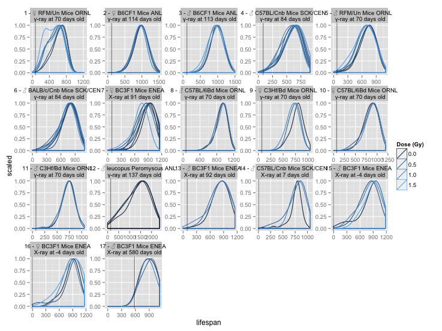

```r
# TODO(later): figure out what is the cause of early effects in ORNL data
# based on the pathology codes released with that dataset.

ggplot(d, aes(lifespan, color = dose, group = factor(paste(dose, dose_rate,
    fractions)), y = ..scaled..)) + geom_density(adjust = 2) + facet_wrap(~cluster,
    scales = "free") + scale_colour_gradient(guide = guide_legend(title = "Dose (Gy)"),
    trans = "sqrt") + geom_vline(aes(xintercept = intended_assignment_age),
    alpha = 0.5) + expand_limits(x = -4)
```

#### Figure: Lifespan by dose and cluster

Density plots show the frequency, y-axis, of a given lifespan (in days), x-axis. Sepperate density curves are shown for each distinct dose and dose rate. The total dose delivered is labeled by color as shown in the figure legend. The mean age at first exposure is denoted by a gray vertical line on each graph.

##### Related observations:

- **Different clusters show very different responses to the same total dose.** For example, compare Female RFM/UN Mice from ORNL (1) to Female C57Bl/6Bd mice from the same institution (10). The only difference between these experiments is the strain of mice used. The former show a strong response to gamma rays, the latter a weak response or no response. These differences could reflect strain-specific differences in radiosensitivity or methodological errors in the way that the studies were conducted.
- **The cluster used to estimate DDREF shows a particularly strong and early response**. RFM/Un mice from ORNL were used as the acute condition in the estimate of DDREF from BEIR VII (chronic exposure is not shown here because individual level data is not available). Notably, this is the strongest radiation response seen in any cluster, including other similar ones from ORNL. Moreover, the response is bimodal, with an early effect that is not seen in other clusters. This suggests that the acute effects are being over-estmimated in BEIR VII and that DDREF should be closer to one.

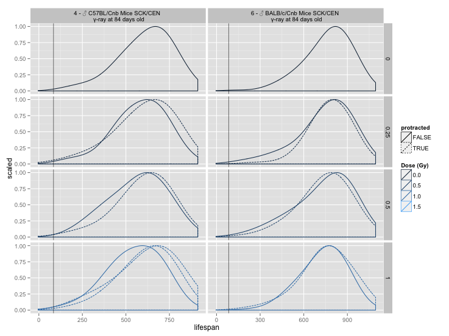

```r
n_unique <- function(...) length(unique(paste(...)))

comparable_doses <- d %.% ungroup() %.% group_by(cluster_id, dose) %.% summarize(n_groups = n_unique(fractions,
    dose_rate)) %.% filter(n_groups > 1)

g <- d %.% ungroup() %.% filter(cluster_id %in% comparable_doses$cluster_id,
    dose %in% c(comparable_doses$dose, 0))

ggplot(g, aes(lifespan, color = dose, group = factor(paste(dose, dose_rate,
    fractions)), linetype = protracted, y = ..scaled..)) + geom_density(adjust = 2) +
    facet_grid(dose ~ cluster, scales = "free") + scale_colour_gradient(guide = guide_legend(title = "Dose (Gy)"),
    breaks = c(0, 0.5, 1, 1.5), limits = c(0, 1.5)) + geom_vline(aes(xintercept = intended_assignment_age),
    alpha = 0.5) + expand_limits(x = -4)
```

#### Figure: Directly comparable protracted exposures

Similar to the figure above, except that the data has been limited to those cases were there are two groups in the same cluster with the same dose, but differences in dose rate or number of fractions. Doses that were delivered more slowly are labeled as protracted (dashed line). Facets of the graph are defined by cluster and total dose delivered. Controls are included for comparison.

##### Additional details

In cluster 4, doses were broken into 10 or 8 fractions seperrated by three hours or 1 day respectively. In cluster 6 doses were broken into 10 fractions sepperated by one day. Notably both of these experiments were conducted at the same laboratory (SCK/CEN) using the same irradiator (a CS-137 source).

*Note, ORNL also conducted experiments with directly comparable doses both acute and protracted, but individual level data is not avaiable for the acute exposures.

##### Observations

The effects of fractionation are decidely ambivilant. Cluster 4 shows signs of high DDREF, cluster 6 shows signs of a DDREF close to 1. The only substantial difference between these experiments is the strain used. Three facts might account for this observation, perhaps DDREF is strain specific, perhaps there were methodological errors in the way these studies were conducted, or perhaps random events are obscuring the true pattern.

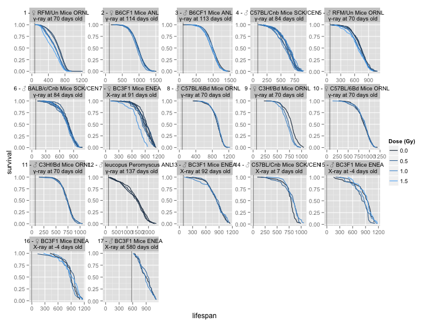

```r
d <- d %.% group_by(cluster, dose, dose_rate, fractions) %.% arrange(lifespan) %.%
    mutate(survival = rank(-lifespan)/length(lifespan))

ggplot(d, aes(lifespan, survival, color = dose, group = factor(paste(dose, dose_rate,
    fractions)))) + geom_path() + facet_wrap(~cluster, scales = "free") + scale_color_continuous(guide = guide_legend(title = "Dose (Gy)"),
    trans = "sqrt") + geom_vline(aes(xintercept = intended_assignment_age),
    alpha = 0.5) + expand_limits(x = -4)
```

#### Figure: Survival plots

As before, but presented as traditional survival plots instead. The y axis represents the fraction of animals alive a at a given time. Other elements are organizeds as before.

##### Related observations

This does not tell us anything new, I've included it because survival plots are standard. Personally I find them less informative than the lifespan density plots shown above.

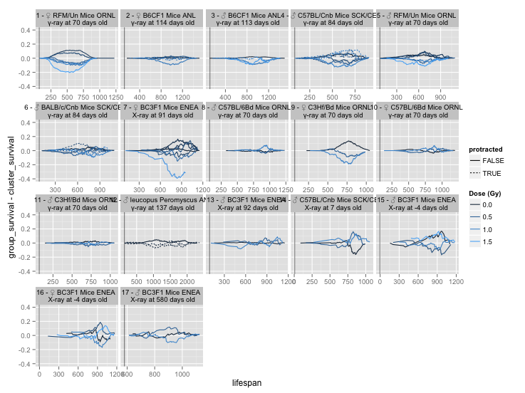

```r
d <- d %.% ungroup() %.% group_by(cluster, dose, dose_rate, fractions) %.% arrange(lifespan) %.%
    mutate(group_survival = rank(-lifespan)/length(lifespan))

# How many animals were alive after X days in each cluster?
d <- d %.% ungroup() %.% group_by(cluster) %.% arrange(lifespan) %.% mutate(cluster_survival = rank(-lifespan)/length(lifespan))

ggplot(d, aes(lifespan, group_survival - cluster_survival, color = dose, linetype = protracted,
    group = factor(paste(dose, dose_rate, fractions)))) + geom_path() + facet_wrap(~cluster,
    scales = "free_x") + scale_color_continuous(guide = guide_legend(title = "Dose (Gy)"),
    trans = "sqrt") + geom_vline(aes(xintercept = intended_assignment_age),
    alpha = 0.5) + ylim(-0.4, 0.4)
```

#### Figure: Relative survival plots

##### Related observations

- **Useful graph, but difficult to interpret** This is actually one of my favorite visualizations of this data because it really uses all of the space of the graph to convey information. However, it takes some thought to wrap one's head around it, so it might not be suitable for presentation in a paper.
- **Cluster 1 does not look as extreme in this graph** It is clear that some clusters show effects roughly as strong as cluster 1 (the cluster used to estimate acute effects in the DDREF estimate). Concretely clusters 7 (Female BC3F1 mice) and 9 (Female C3Hf/Bd Mice) have responses of similar strength. Still, no responses happen as early as those in cluster 1, so it is still a suspicious case suggesting that DDREF has been over-estimated.
- **Protraction appears to alievate or eliminate the effects of exposure** In this graph it was possible to meaningfully show protracted groups. The general trend is that protraction seems to be beneficial. This is especially obvious in cluster 4, but generally corroborated with clusters 2, 3, and 6 in which the protracted treatment groups tend to cluster with the control and low dose groups.

^ back to table of contents

# Atomic bomb survivor data

*Last update: April 2014*

For comparison, let's load data from the atomic bomb survivors, [lss14](http://rerf.jp/library/dl_e/lss14_document.pdf), and see how lifespan changes as a function of dose in these populations using similar visualizations.

Acknowledgement: This report makes use of data obtained from the Radiation Effects Research Foundation (RERF), Hiroshima and Nagasaki, Japan. RERF is a private, non-profit foundation funded by the Japanese Ministry of Health, Labour and Welfare and the U.S. Department of Energy, the latter through the National Academy of Sciences.The conclusions in this report are those of the authors and do not necessarily reflect the scientific judgment of RERF or its funding agencies. Please send a copy of any reprints that make use of these data to: Archives Unit, Library and Archives Section Department of Information Technology Radiation Effects Research Foundation 5-2 Hijiyama Park Minami-ku Hiroshima, 732-0815 JAPAN

```r
# Libraries
library(dplyr)
library(plyr)

# Helper functions
get_max_map <- function(min_map, max = Inf) {
    max_map <- c(min_map[2:length(min_map)], max)
    names(max_map) <- names(min_map)
    max_map
}
get_mean_map <- function(min_map, max = Inf) {
    mean_map <- (min_map + get_max_map(min_map, max))/2
    mean_map
}

# Load data
setwd("~/janus/")
data <- read.csv("data/lss14/lss14.csv")

# Define Terms
sex_map <- c(`1` = "♂", `2` = "♀")
agecat_min_map <- c(`1` = 0, `2` = 5, `3` = 10, `4` = 15, `5` = 20, `6` = 25,
    `7` = 30, `8` = 35, `9` = 40, `10` = 45, `11` = 50, `12` = 55, `13` = 60,
    `14` = 65, `15` = 70, `16` = 75, `17` = 80, `18` = 85, `19` = 90, `20` = 95,
    `21` = 100)

agecat_mean_map <- get_mean_map(agecat_min_map, 120)
dose_min_map <- c(`1` = 0, `2` = 0.005, `3` = 0.02, `4` = 0.04, `5` = 0.06,
    `6` = 0.08, `7` = 0.1, `8` = 0.125, `9` = 0.15, `10` = 0.175, `11` = 0.2,
    `12` = 0.25, `13` = 0.3, `14` = 0.5, `15` = 0.75, `16` = 1, `17` = 1.25,
    `18` = 1.5, `19` = 1.75, `20` = 2, `21` = 2.5, `22` = 3)
dose_mean_map = get_mean_map(dose_min_map, 4)

ctime_min_map <- c(`1` = 1951, `2` = 1956, `3` = 1961, `4` = 1966, `5` = 1971,
    `6` = 1976, `7` = 1981, `8` = 1986, `9` = 1991, `10` = 1996, `11` = 2001)

threshold = 1.5001

# Fix data
data <- data %.% # Translate Values into different units
mutate(sex = sex_map[sex], agex = agecat_min_map[agexcat], age = agecat_min_map[agecat],
    dose = dose_mean_map[dosecat], ctime = ctime_min_map[ctime]) %.% # Thin Only select the colums of interest
select(city, sex, agex, age, dose, subjects, death, ctime) %.% # Shorten Remove those with a dose above threshold
filter(dose < threshold)

# One row per death
dead <- ldply(unique(data$death), function(n) {
    d <- data[data$death == n, ]
    d[rep(1:nrow(d), n), ]
})

# Prove it was actually done
sum(data$death) == 49879
```

```
## [1] TRUE
```

```r
nrow(dead) == 49879
```

```
## [1] TRUE
```

```r
# Clean dead Make it truly represent one individual per row by removing
# aggregated values
dead <- dead %.% select(-subjects, -death) %.% mutate(alive = 0)

# One row for each person still alive Note, defining the minimum age for
# people still alive is a little challenging because the relationship
# between age and calendar time is not one to one.  Concretely someone
# exposed at age 0-5 might be 5, 10, or 15 years old in 1950
table0(dead$age[dead$agex == 0 & dead$ctime == 1951])
```

```
##
##  5 10 15
## 27 15  1
```

```r
# this makes it difficult to know their projected age at some later date,
# like 2004.
#
# To overcome this challenge we will calculate the distribution of min
# calendar time - min age for a given age at exposure and use this
# distribution of difference to project a distribution of min ages for a
# new calendar time (2004 and later, for which we have no more data.
living <- ddply(data, .(agex, dose, city, sex), function(df) {
    subjects = sum(df$subjects)
    dead = sum(df$death)
    living = subjects - dead
    .all <- function(x) unique(df[x])

    if (living == 0) {
        return(NULL)
    }

    # There should be one row for each living person and age should be a
    # distribution.  see explanation above
    same_agex = data[data$agex == df$agex[1], ]
    age = sample(with(same_agex, 2004 + age - ctime), size = living, replace = TRUE)

    data.frame(city = .all("city"), sex = .all("sex"), agex = .all("agex"),
        age = age, dose = .all("dose"), ctime = 2004, alive = 1)
})

# Merge living and dead
long <- rbind(dead, living)

# Prove that long is the correct size
nrow(long) == 85498
```

```
## [1] TRUE
```

```r
sum(data$subjects) == 85498
```

```
## [1] TRUE
```

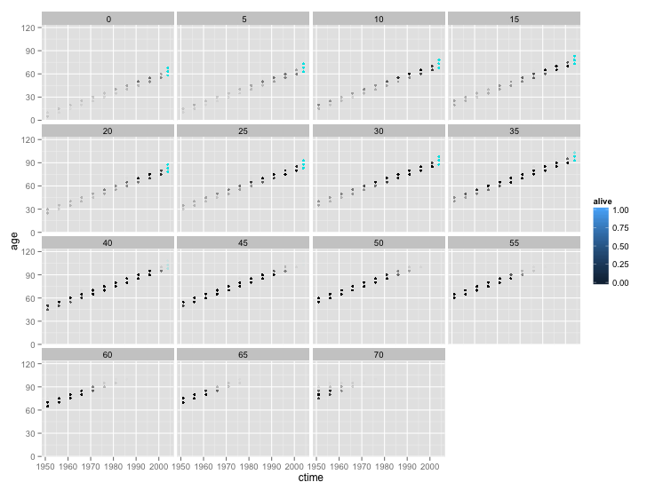

```r
# Prove that ages look reasonable
ggplot(long, aes(ctime, age, color = alive)) + geom_point(alpha = 0.002) + facet_wrap(~agex)
```

```r
# Reduce resolution (as it is there are too many categories for graphing)
low_res <- long %.% mutate(agex = floor(agex/20) * 20, age_string = paste0(agex,
    "+ years"), lifespan = age, dose = round(dose * 2)/2)
```

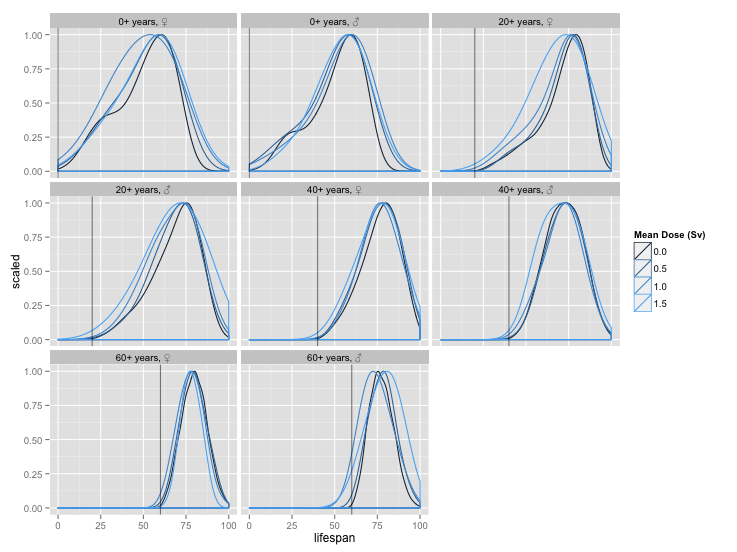

```r
g <- low_res
# Show it off
ggplot(g %.% filter(!alive), aes(x = lifespan, color = dose, group = factor(paste0(dose)),
    y = ..scaled..)) + geom_density(adjust = 2) + scale_colour_gradient(guide = guide_legend(title = "Mean Dose (Sv)"),
    trans = "sqrt", breaks = c(0, 0.5, 1, 1.5), limits = c(0, 1.5)) + geom_vline(aes(xintercept = agex),
    alpha = 0.5) + facet_wrap(~age_string + sex) + xlim(0, 100)
```

#### Figure: LSS lifespan by dose, sex, and age at exposure

##### Related observations

- **Artifacts are introduced by those still alive** Most survivors expososed at 0-20 years old and many survivors exposed at 20-40 years old are still alive. That means that only the 40+ year old survivors represent a complete dataset.
- **Effect are not as strong as those seen in ORNL data** qualitatively the effects of radiation exposure seem milder than those observed in the ORNL data set. Thse are no strong signs of an early effect.

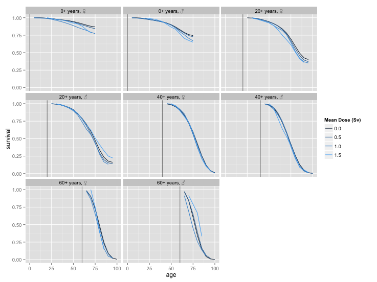

```r
# Note by multiplying age * alive plus a small amount we ensure that
# survivors who are still alive always have a higher rank than those that
# have already died.
g <- low_res %.% group_by(agex, dose, sex) %.% arrange(age) %.% mutate(survival = rank(-age *
    (alive + 1e-04))/length(age))

ggplot(g %.% filter(!alive), aes(age, survival, color = dose, group = factor(dose))) +
    geom_path() + facet_wrap(~age_string + sex) + scale_colour_gradient(guide = guide_legend(title = "Mean Dose (Sv)"),
    trans = "sqrt", breaks = c(0, 0.5, 1, 1.5), limits = c(0, 1.5)) + geom_vline(aes(xintercept = agex),
    alpha = 0.5)
```

#### Figure: LSS survival by dose, sex, and age at exposure

As before.

##### Observations

- **Not as extreme as ORNL** This view shows more strongly that the effects seen in the ORNL data used in DDREF analysis were stronger than those seen in the atomic bomb survivors.

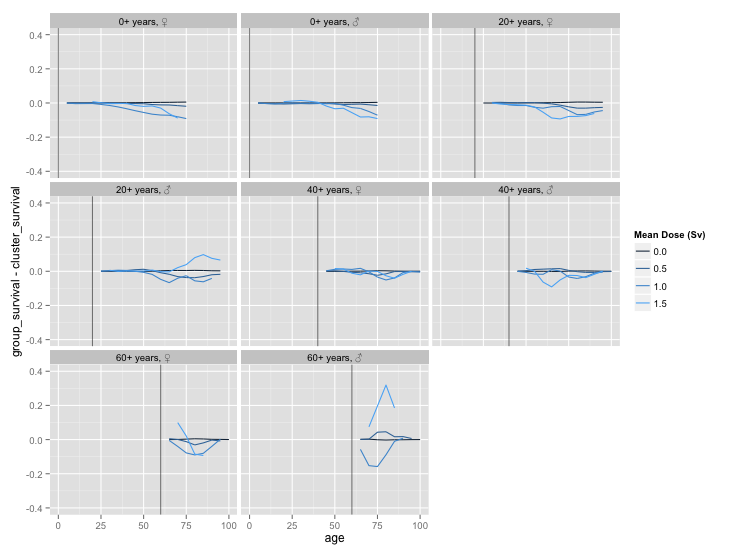

```r
g <- low_res %.% ungroup() %.% group_by(agex, dose, sex) %.% arrange(age) %.%
    mutate(group_survival = rank(-age * (alive + 1e-04))/length(age))

# How many people were alive after X years in each cluster?
g <- g %.% ungroup() %.% group_by(agex, sex) %.% arrange(age) %.% mutate(cluster_survival = rank(-age *
    (alive + 1e-04))/length(age))

ggplot(g %.% filter(!alive), aes(age, group_survival - cluster_survival, color = dose,
    group = factor(dose))) + geom_path() + facet_wrap(~age_string + sex) + scale_colour_gradient(guide = guide_legend(title = "Mean Dose (Sv)"),
    trans = "sqrt", breaks = c(0, 0.5, 1, 1.5), limits = c(0, 1.5)) + geom_vline(aes(xintercept = agex),
    alpha = 0.5) + ylim(-0.4, 0.4)
```

#### Figure: Relative LSS survival

As with the animal data we the difference between survival of an entire cluster (defined by age of exposure and sex) and a group exposed to a particular dose within that group.

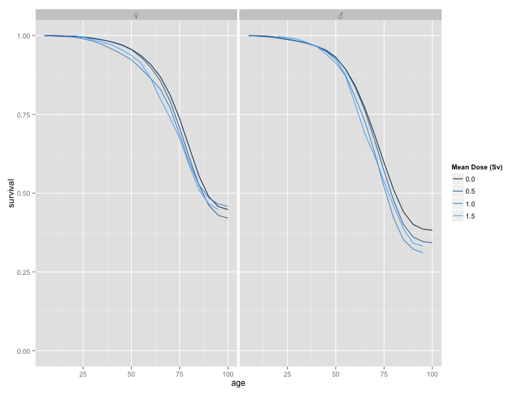

```r
# TODO(later): It would be reasonable to add animals exposed at different
# ages to the same cluster, just as I did for the atomic bomb survivors.
# I only need to be sure that I calculate survival based on the total
# still alive

# Reduce dose resolution We want less dose categories total, but agex
# resolution should not be reduced
g <- long %.% mutate(dose = round(dose * 2)/2)

# Determine survival
#
# Survival should include the number of people alive at a given age and
# the number of people that are at risk at that same age.  Because some
# people were irradiated at an older age they should be included in the
# total at risk only at ages
#
# Note by multiplying age * alive plus a small amount we ensure that
# survivors who are still alive always have a higher rank than those that
# have already died.

g <- g %.% group_by(dose, sex) %.% arrange(age) %.% mutate(n_alive = rank(-age *
    (alive + 1e-04)), n_at_risk = rep(sum(agex <= age), length(age)), survival = n_alive/n_at_risk)

ggplot(g %.% filter(!alive), aes(age, survival, color = dose, group = factor(dose))) +
    geom_path() + facet_wrap(~sex) + scale_colour_gradient(guide = guide_legend(title = "Mean Dose (Sv)"),
    trans = "sqrt", breaks = c(0, 0.5, 1, 1.5), limits = c(0, 1.5)) + ylim(0,
    1)
```

#### LSS survival by sex

As before except that all age at first exposures are combined into a single graph. The total survival is calcualated by the number of people alive at a given age divided by the number of people who were exposed at that same age or younger.

##### Related observations

**Less noisy** This looks like the stratified graphs from before, but is noticibly less noisy. There is a reasonably clean relationship between dose and life shortening. **Shows the effect of irradiating a population** Unlike the previous graphs, this shows the effects or irradiating an entire population all at once. **May mask age specific reactions** The stratified graph left the mild impression that exposure to younger population might be more damaging. If this is true, then this graph completely masks that effect.

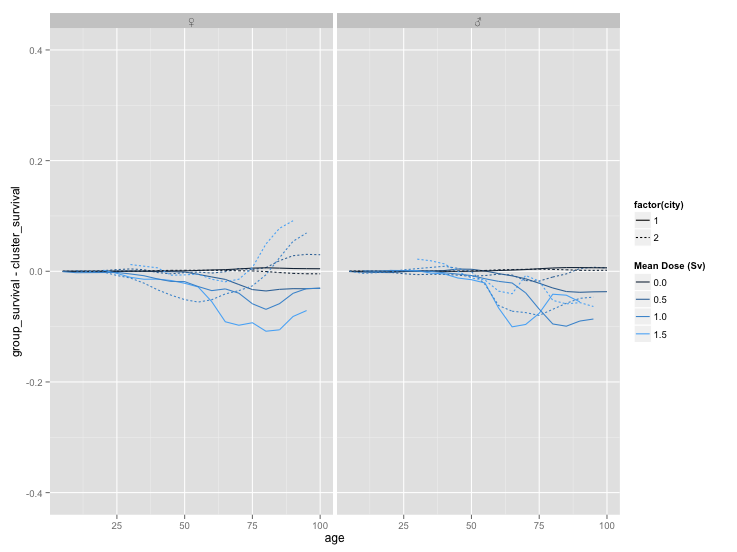

```r
# How many people were alive after X years in each group?
g <- g %.% ungroup() %.% group_by(dose, sex, city) %.% arrange(age) %.% mutate(n_alive = rank(-age *
    (alive + 1e-04)), n_at_risk = rep(sum(agex <= age), length(age)), group_survival = n_alive/n_at_risk)

# How many people were alive after X years in each cluster?
g <- g %.% ungroup() %.% group_by(sex, city) %.% arrange(age) %.% mutate(n_alive = rank(-age *
    (alive + 1e-04)), n_at_risk = rep(sum(agex <= age), length(age)), cluster_survival = n_alive/n_at_risk)

ggplot(g %.% filter(!alive), aes(age, group_survival - cluster_survival, color = dose,
    linetype = factor(city), group = factor(paste0(dose, city)))) + geom_path() +
    facet_wrap(~sex) + scale_colour_gradient(guide = guide_legend(title = "Mean Dose (Sv)"),
    trans = "sqrt", breaks = c(0, 0.5, 1, 1.5), limits = c(0, 1.5)) + ylim(-0.4,
    0.4)
```

#### Relative LSS survival by sex

As before, but now we show the difference between survival at a given dose and the overall survival of the cohort.

##### Related observations

- **Same story, less noise** This graph tells the same story as before, with substantially less noise. At its maximum survival, ~75 years old, the difference in survival between people irradiated at > 1 Gy might be 10% of the population. This is a sizable difference to be sure, but not even close to what was seen in the ORNL data.

^ back to table of contents

# Reproduce BEIR 10B2

*Last update: May 2014*

Reproduce Figure 10B2 estimated DDREF using cancer incidence data.

### Their approach

BEIR VII used total lifetime cancer indicence adjusted for competing risks for a variety of tumor endpoints. They only included acute exposures and purposefully excluded various cancer endpoints.

- [BEIR VII pg 254](http://www.nap.edu/openbook.php?record_id=11340&page=254)

Models were fit as in 10B3 by fitting linear quadratic models to mean incidence rates per group with a fixed curvature, o. Concretely:

`mean incidence rate ~ a * dose + o * a * dose^2`

TODO: determine how this adjustment for competing risks was performed?

### The data source

Edwards, A.A. 1992. Low Dose and Low Dose Rate Effects in Laboratory Animals, Technical Memorandum 1(92). Chilton, UK: National Radiological Protection Board.

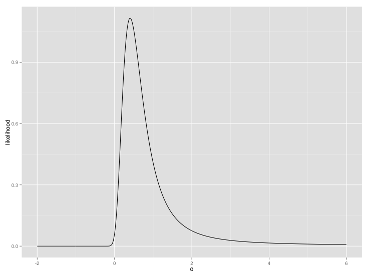

```r
# TODO: 10B2 needs to also use meta regression as in 10B4 to see how that
# influences the effect

library(plyr)
library(dplyr)
library(ggplot2)

# Data
setwd("~/janus")
source("scripts/util/util.R")
data <- read.csv("data/edwards_1992.csv", sep = "\t")

normalize_likelihood <- function(l, delta) {
    l <- l - max(l)
    l <- exp(l)
    l <- l/sum(l)
    l <- l/delta

    l
}

# apply selection criteria
data <- data %.% filter(protraction == "Acute", !is.na(risk), dose <= 2)

# Fit model to each facet
data <- ddply(data, .(facet), function(df) {
    model <- lm(risk ~ dose + I(dose^2), df, weights = (1/error^2))
    df$seperate_prediction <- predict(model)
    df
})


# Fit models to all data vary curvature and measure total likelihood of
# each model
low = -2
high = 6
delta = 0.01
o_range = (low/delta):(high/delta) * delta
fits <- ldply(o_range, function(o) {
    model <- lm(risk ~ factor(facet) * I(dose + o * dose^2), data, weights = (1/error^2))
    c(o = o, likelihood = logLik(model))
})

fits <- fits %.% mutate(likelihood = normalize_likelihood(likelihood, delta))

ggplot(fits, aes(o, likelihood)) + geom_path()
```

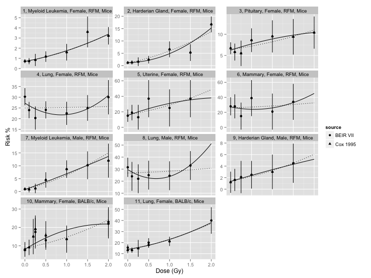

```r
# Make predictions for most likely model
o = with(fits, o[which.max(likelihood)])
model <- lm(risk ~ factor(facet) * I(dose + o * dose^2), data, weights = (1/error^2))
data$single_prediction <- predict(model)


# Plot a reproduction of 10B2
ggplot(data, aes(x = dose, y = risk, ymin = risk - error * 2, ymax = risk +
    error * 2, 32)) + geom_point(aes(shape = source)) + geom_pointrange(aes(ymin = risk -
    error * 2, ymax = risk)) + geom_pointrange(aes(ymin = risk, ymax = risk +
    error * 2)) + geom_smooth(aes(x = dose, y = seperate_prediction), method = "lm",
    formula = "y ~ x + I(x^2)", fullrange = TRUE, color = "black") + geom_smooth(aes(x = dose,
    y = single_prediction), method = "lm", formula = "y ~ x + I(x^2)", fullrange = TRUE,
    color = "black", linetype = "dotted") + facet_wrap(~facet + cancer + sex +
    strain + species, scales = "free_y", ncol = 3) + xlim(0, 2) + xlab("Dose (Gy)") +
    ylab("Risk %")
```

```r
# save fits for use in 10B4
write.csv(fits, "data/10B2_fits.csv")
```

#### Figure: 10B2 reproduction

A direct reproduction of figure 10B2 from the BEIR VII report.

##### 10B2

This is the original [10B2 figure](http://www.nap.edu/openbook.php?record_id=11340&page=258) from the beir VII report [beir-10b2].

[figure not shown]

##### Observations

- **We can reproduce BEIR VII** This graph provides visual evidence that we can accurately reproduce best fit lines used for DDREF estimation from cancer data. These likelihoods will be combined with DDREF estimates from atomic bomb survivors and animal lifespan studies to provide a final estimate of DDREF. Only the lifespan estimates are to be updated by this work, but these other estimates must be faithfully reproduced so that they can compbine with the modified lifespan estimates to provide a final modified estimate of DDREF.

# Reproduce BEIR 10B3

*Last update: June 2013*

Reproduce the BEIR estimates on the oak ridge lifespan data from storer 1979 (3575012.pdf).

```r
# Libraries
library(ggplot2)
library(plyr)

# Data
setwd('~/janus')
source('scripts/util/util.R')
data <- read.csv('data/storer_1979.csv', sep='\t')


model_10B3 <- function(data){
    glm(
        I(1/age) ~ dose + I(dose^2 / (fractions)),
        data=data,
        weights=n
    )
}
show <- function(g){
    original <- g[is.na(g$p_10B3),]
    predictions <- g[!is.na(g$p_10B3),]
    suppressWarnings(print(
    ggplot(original, aes(
        dose,
        1/age,
        label=type,
        group=type
    )) +
        geom_text(size=5) +
        geom_smooth(
            data=predictions,
            aes(dose, p_10B3),
            color='black'
        ) # +
        # geom_smooth(
            # data=predictions,
            # aes(dose, p_my_analysis),
            # color='red'
        # )
    ))
}


# Constants
threshold = 1.5001

# Prediction Intervals
to_predict <- expand.grid(
    fractions = c(1, 1000),
    dose = seq(0, 1.5, 0.1)
)
to_predict$type <- 'A'
to_predict$type[to_predict$fractions > 1] <- 'C'

# Clean
data$fractions <- 1
data$fractions[data$rate < 0.1] <- Inf

# Define Acute
chronic <- data$rate < 0.1
data$type <- 'A'
data$type[chronic] <- 'C'

# Subset
data$modeled_in_10B3 <- with(data,
    dose < threshold &
    strain == 'RFM'  &
    sex == 'F' &
    rate != 0.4
)
data$in_my_analysis <- data$type == 'A'

# prediction matrix
predictions <- to_predict
addin <- names(data)[!names(data) %in% names(predictions)]
predictions <- merge(data[1, addin], predictions, all=TRUE)

# 10B3 Model
m <- model_10B3(data[data$modeled_in_10B3,])
predictions$p_10B3 <- predict(m, newdata=predictions)

# My Model
s <- data$modeled_in_10B3 &
     data$in_my_analysis
m <- model_10B3(data[s,])
predictions$p_my_analysis <- predict(m, newdata=predictions)

# Merge
data$p_10B3 <- NA
data$p_my_analysis <- NA

data <- rbind(predictions, data)
```

#### Show

##### 10B3

This is the original [10B3 figure](http://www.nap.edu/openbook.php?record_id=11340&page=257) from the beir VII report [beir-10b3].

[figure not shown]

##### Reproduce 10B3

This is my reproduction of 10B3 to prove that I am faithfully applying their methodology.

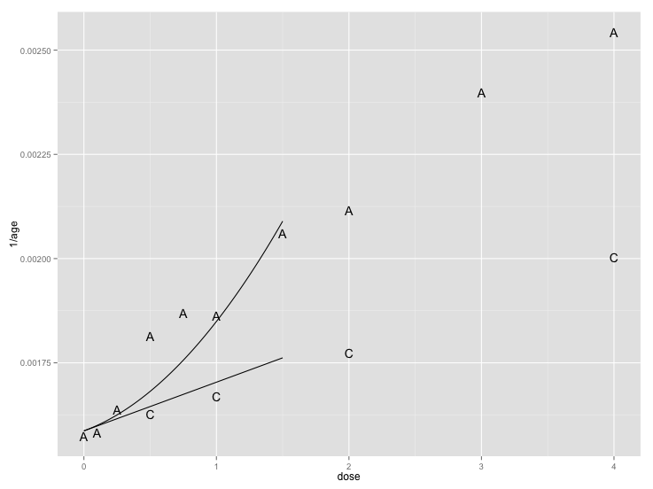

```r
g <- data[with(data, strain == "RFM" & sex == "F" & rate != 0.4), ]
show(g)
```

```r
ggsave_for_ppt("beir_10B3_reproduction.png")
```

### Results

I am capable of reproducing their results. There are two tricks

1. They stratified by strain and gender
2. They weighted by n

Strangely, they do not include data from table 2, but when I add this in, it does not make a huge difference, so I assume they are just not being careful.

^ back to table of contents

# Reproduce BEIR 10B4

*Last update: May 2014* Reproduce the BEIR estimates on the oak ridge lifespan data from storer 1979 (3575012.pdf).

```r
# Libraries
library(ggplot2)
library(plyr)

# Data
setwd('~/janus')
data <- read.csv('data/storer_1979.csv', sep='\t')
data_10B2 <- read.csv('data/10B2_fits.csv')

model_10B4 <- function(data, o){
    glm(
        I(1/age) ~ I(dose + o*dose^2 / (fractions)),
        data=data,
        weights=n
    )
}
normalize_likelihood <- function(l, delta){
    l <- l - max(l)
    l <- exp(l)
    l <- l / sum(l)
    l <- l / delta

    l
}

# Constants
threshold = 1.5001

# Clean
data$fractions <- 1
data$fractions[data$rate < 0.1] <- Inf

# Define Acute
chronic <- data$rate < 0.1
data$type <- 'A'
data$type[chronic] <- 'C'

# Subset
data$modeled_in_10B4 <- with(data,
    dose < threshold &
    strain == 'RFM'  &
    sex == 'F' # &
    # rate != 0.4
)
data$in_my_analysis <- data$type == 'A'

# Model
low = -2
high = 6
delta = .01
o_range = (low/delta):(high/delta) * delta

get_likelihoods <- function(o_range, data){
    r <- ldply(o_range, function(o){
        m <- model_10B4(data, o)
        l = logLik(m)

        data.frame(o, l)
    })

    r$l <- normalize_likelihood(r$l, delta)

    r
}

beir_r <- get_likelihoods(o_range, data[data$modeled_in_10B4,])
my_r <- get_likelihoods(o_range, data[data$in_my_analysis,])


# Merge likelihoods with data from 10B2
alignment <- match( round(beir_r$o, 5),
                    round(data_10B2$o, 5))
beir_r <- beir_r %.%
  mutate(tumor_likelihood = data_10B2$likelihood[alignment],
         lifespan_likelihood = l,
         mean_likelihood = (tumor_likelihood+lifespan_likelihood)/2) %.%
  select(-l)
my_r <- my_r %.%
  mutate(tumor_likelihood = data_10B2$likelihood[alignment],
         lifespan_likelihood = l,
         mean_likelihood = (tumor_likelihood+lifespan_likelihood)/2) %.%
  select(-l)
```

#### Show

##### 10B4

This is the original [10B4 figure](http://www.nap.edu/openbook.php?record_id=11340&page=258) from the beir VII report [beir-10b4].

[figure not shown]

##### Reproduce 10B4

This is my reproduction of 10B4 to prove that I am faithfully applying their methodology.

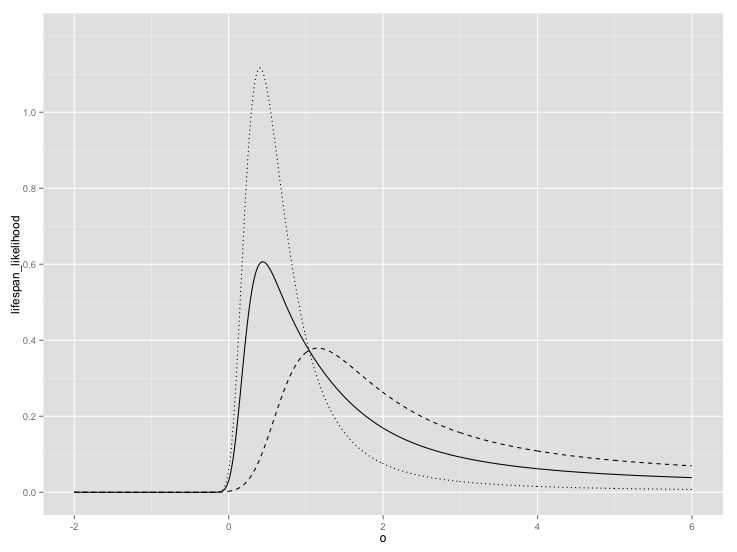

```r
ggplot(beir_r, aes(o)) + geom_path(aes(y = lifespan_likelihood), linetype = "dashed") +
    geom_path(aes(y = tumor_likelihood), linetype = "dotted") + geom_path(aes(y = mean_likelihood)) +
    scale_y_continuous(breaks = c(0:5)/5, limits = c(0, 1.2))
```

##### Updated 10B4

What would the profile likelihood be if the new estimates were used instead?

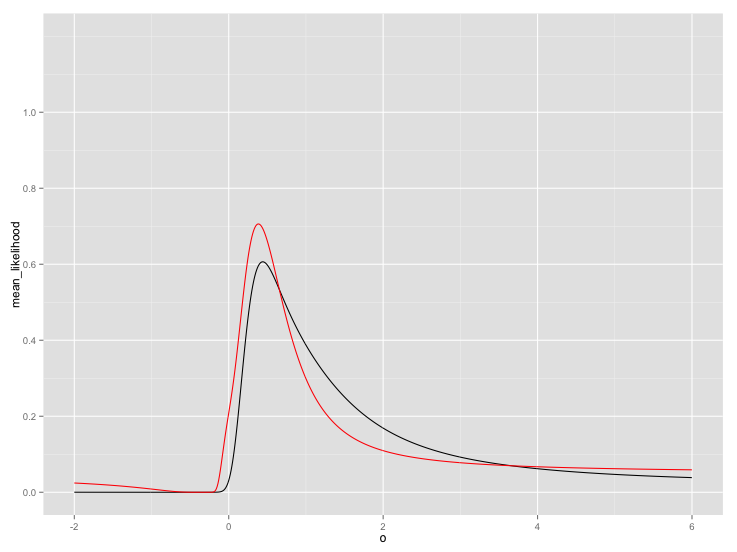

```r
ggplot(beir_r, aes(o)) + geom_path(aes(y = mean_likelihood)) + geom_path(data = my_r,
    aes(y = mean_likelihood), color = "red") + scale_y_continuous(breaks = c(0:5)/5,
    limits = c(0, 1.2))
```

#### Results

It could be that the shoulder is very narrow, though this would be surprising given what we know about tissue level effects.

It could also be that there is some systematic bias between chronic and high dose experiments. For instance the high dose rate was even higher than the experimenters thought that it was.

More reason for meta-analysis.

^ back to table of contents

# 1/lifespan on all data

*Last update: June 2013*

Show graphs like Storer 1979 10-B3 but for all data.

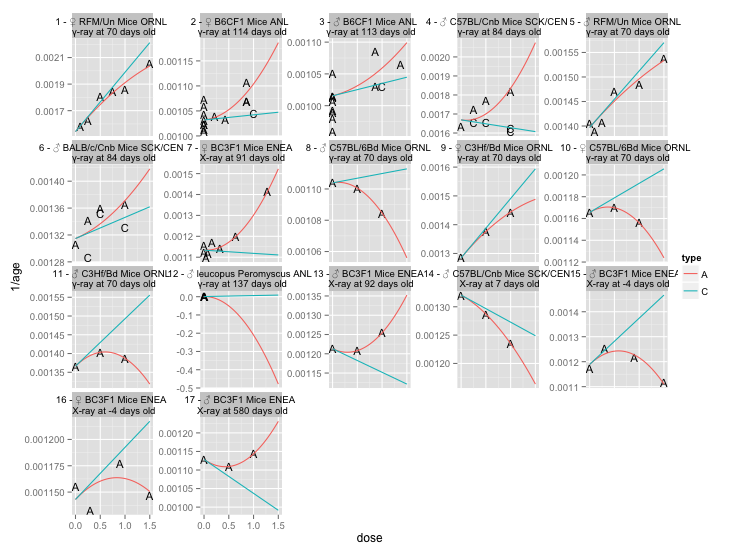

```r
# Libraries
setwd("~/janus")
source("scripts/util/util.R")
library(ggplot2)
library(plyr)

# Data
data <- readRDS("data/ddref.rds")

# Helpers
model_10B3 <- function(data) {
    glm(I(1/age) ~ dose + I(dose^2/(fractions)), data = data, weights = n)
}
show <- function(g) {
    f <- function(x) round(x, 2)
    suppressWarnings(print(ggplot(g[is.na(g$p), ], aes(dose, 1/age, label = type,
        group = type)) + geom_text(size = 4) + geom_smooth(data = g[!is.na(g$p),
        ], aes(dose, p, color = type), method = "lm", formula = "y ~ x + I(x^2)",
        se = FALSE) + facet_wrap(~cluster, scales = "free_y")))
}

# Prediction Intervals
to_predict <- expand.grid(fractions = c(1, 1000), dose = seq(0, 1.5, 0.1))
to_predict$type <- "A"
to_predict$type[to_predict$fractions > 1] <- "C"


# Mean Lifespans
aggregate <- ddply(data, .(cluster, group_id, sex), function(df) {
    u <- function(x) paste(unique(x), collapse = " ")
    dont_aggregate <- c("lifespan", "id", "X", "n")
    data.frame(llply(df[, !names(df) %in% dont_aggregate], u), age = mean(df$lifespan),
        age_sd = sd(df$lifespan), n = nrow(df))
})

# Restore Sanity
numerics <- names(data)[laply(data, is.numeric)]
for (n in numerics) {
    if (n %in% names(aggregate)) {
        aggregate[, n] <- as.numeric(as.character(aggregate[, n]))
    }
}

# Model
m <- c("cluster", "sex", "cluster")
df <- aggregate[aggregate$cluster == aggregate$cluster[1] & aggregate$sex ==
    aggregate$sex[1] & aggregate$cluster == aggregate$cluster[1], ]
aggregate <- ddply(aggregate, .(cluster, sex, cluster), function(df) {
    # Extract Coefficients
    m <- model_10B3(df)
    c <- m$coefficients
    df$a <- c["dose"]
    df$B <- c["I(dose^2/(fractions))"]

    # Extract Predictions
    predictions <- to_predict
    addin <- names(df)[!names(df) %in% names(predictions)]
    predictions <- merge(df[1, addin], predictions, all = TRUE)
    predictions$p <- predict(m, newdata = predictions)

    # merge
    df$p <- NA
    out <- rbind(df, predictions)

    out
})

# TODO(later) change the colors in order to make the theme consistent
# throughout the presentation.  I recommend black for chronic effects and
# red for accute.  Use transparency to represent my new results when I
# over-lay them so that the old results can still be seen (or visa-versa).


# Show As in 10B3 http://www.nap.edu/openbook.php?record_id=11340&page=257
a <- aggregate
g <- a
show(g)
```

```r
ggsave_for_ppt("inverse_lifespan.png")
```

#### Results

This data is far from well behaved!

Chronic effects may appear better or worse than projected acute effects. Sometimes hormesis like respsonses appear. Its not obvious from this graph because the y-axis is stretched to fit the data, but the magnitude of the effect is changing wildly too.

It is no wonder that radiobiology is full of debate!

At this point we should be a bit skeptical of organizing the data in this, the BEIR VII manner. While that approach seemed reasonable given the ORNL data that they worked with, it clearly does not generalize well. This may be because the underlying statitical approach is flawed, or simply that these graphs a very robust way of displaying the effect. In any case we question the 'intuitive appeal' of graph 10B3. While it seemed quite difinitive in isolation, the effect is lost when we try to repeat it on new datasets.

^ back to table of contents

# 1/lifespan profiles on all data

*Last update: June 2013*

Show graphs like Storer 1979 10B4 but for all data.

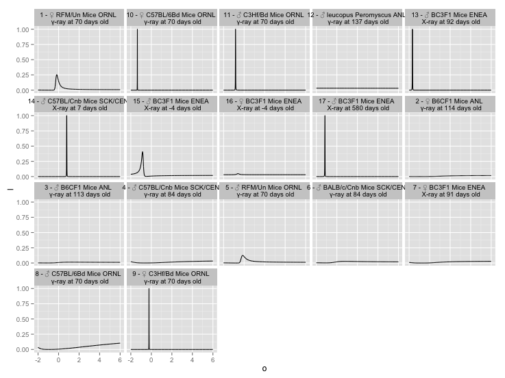

```r
# Libraries
library(ggplot2)
library(plyr)

# Data
setwd("~/janus")
data <- readRDS("data/ddref.rds")


# Helpers
model_10B4 <- function(data, o) {
    glm(I(1/age) ~ I(dose + o * dose^2/(fractions)), data = data, weights = n)
}
normalize_likelihood <- function(l, delta) {
    l <- l - max(l)
    l <- exp(l)
    l <- l/sum(l)
    l <- l/delta

    l
}


# Mean Lifespans
aggregate <- ddply(data, .(cluster, group_id, sex), function(df) {
    u <- function(x) paste(unique(x), collapse = " ")
    dont_aggregate <- c("lifespan", "id", "X", "n")
    data.frame(llply(df[, !names(df) %in% dont_aggregate], u), age = mean(df$lifespan),
        age_sd = sd(df$lifespan), n = nrow(df))
})

# Restore Sanity
numerics <- names(data)[laply(data, is.numeric)]
for (n in numerics) {
    if (n %in% names(aggregate)) {
        aggregate[, n] <- as.numeric(as.character(aggregate[, n]))
    }
}


# Model
low = -2
high = 6
delta = 0.01  # decrease for higher resolution
o_range = (low/delta):(high/delta) * delta


# Model
aggregate <- ldply(o_range, function(o) {
    ddply(aggregate, .(cluster, sex), function(df) {

        m <- model_10B4(df, o)
        df$l <- logLik(m)
        df$o <- o
        df
    })
})

# Summarize Effect
summary <- ddply(aggregate, .(o), function(df) {
    sum(df$l, na.rm = TRUE)
})
names(summary) <- c("o", "l")
summary$l <- normalize_likelihood(summary$l, delta)


# Normalize
aggregate <- ddply(aggregate, .(cluster, sex), function(df) {
    df$l <- normalize_likelihood(df$l, delta)
    df
})

# Show As in 10B4 http://www.nap.edu/openbook.php?record_id=11340&page=257
a <- aggregate

show <- function(g) {
    g$cluster <- as.factor(as.character(g$cluster))
    g$l <- pmin(g$l, 1)
    suppressWarnings(print(ggplot(g, aes(o, l)) + geom_path() + ylim(0, 1) +
        facet_wrap(~cluster)))
}
g <- a
show(g)
```

```r
ggsave_for_ppt("inverse_lifespan_profile.png")
```

#### Results

Looks bad, we are way too confident!

^ back to table of contents

# Meta Regression Figure

*Last update: June 2013*

A figure that shows off the principal of meta-regression.

```r
# Libraries
library(ggplot2)
library(plyr)
library(metafor)

# Helpers
ggsave_for_ppt <- function(...) suppressWarnings(ggsave(..., dpi = 100, width = 10.24,
    height = 7.68, units = "in"))


# Fake data
set.seed(1)
sd <- 1
n <- 5
x <- 1:n
v <- rnorm(n)^2
data <- data.frame(yi = rnorm(n, 1:n, sd), vi = v, x = x)

# An outlider
data$yi[3] <- 0
data$vi[3] <- 0.01

# Model
m <- rma(yi, vi, mods = cbind(x), data = data, method = "ML")
data$p <- predict(m)$pred
data$tau2 <- m$tau2

# Predict likelihood
data$o2 <- (data$vi + data$tau2)
data$e <- (data$p - data$yi) * 0.3
n <- nrow(data)
l <- with(data, sum(-(1/2) * sum(e^2/o2) + -(1/2) * log(o2) + -(1/2) * log(2 *
    pi)))
logLik(m)
```

```
## 'log Lik.' -8.707 (df=3)
```

```r
l
```

```
## [1] -7.493
```

```r
df <- 3
Q <- with(data, sum(yi^2/vi))
tau2 = (Q - df)/C
```

```
## Error: non-numeric argument to binary operator
```

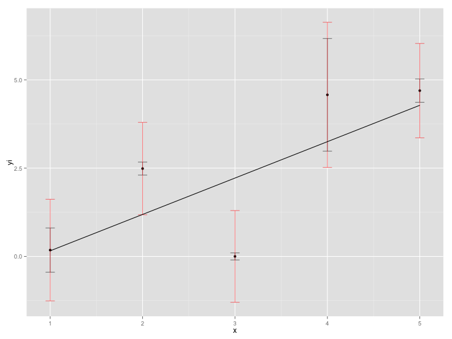

```r
# Show
ggplot(data, aes(x, yi)) + geom_point() + geom_errorbar(aes(ymin = yi - vi^0.5,
    ymax = yi + vi^0.5, ), width = 0.1, alpha = 0.5) + geom_errorbar(aes(ymin = yi -
    (vi + tau2)^0.5, ymax = yi + (vi + tau2)^0.5, ), width = 0.1, alpha = 0.5,
    color = "red") + geom_path(aes(x, p), color = "black")
```

```r
ggsave_for_ppt("meta_regression_example.png")
```

^ back to table of contents

# Meta Regression of BEIR 10B3

*Last update: June 2013*

BEIR fits oak ridge data as if they are points, but actually each point represents many samples and we know the standard deviation of this estimate. Therefore meta-regression is a more appropriate form of analysis. Here we show the fit by meta-regression.

We will also run a heterogeneity test.

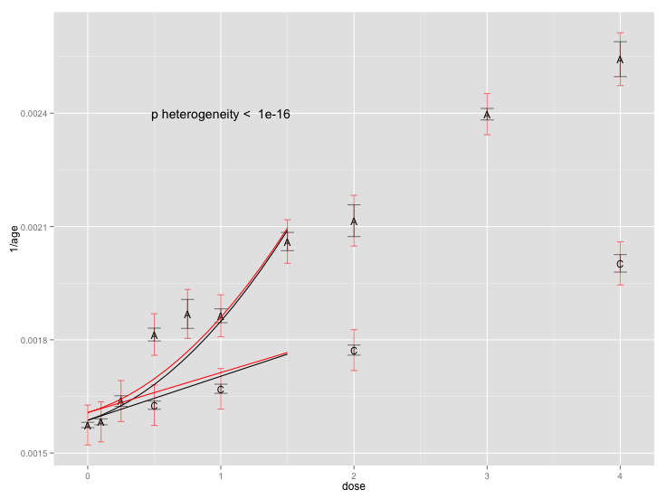

```r
# Libraries
library(ggplot2)
library(plyr)
library(metafor)

# Data
setwd("~/janus")
data <- read.csv("data/storer_1979.csv", sep = "\t")

# Helpers
ggsave_for_ppt <- function(...) suppressWarnings(ggsave(..., dpi = 100, width = 10.24,
    height = 7.68, units = "in"))

model_10B3 <- function(data) {
    glm(I(1/age) ~ dose + I(dose^2/(fractions)), data = data, weights = n)
}
model_meta <- function(data) {
    data$a <- data$dose
    data$B <- with(data, dose^2/(fractions))
    rma(yi, vi, mods = cbind(a, B), data = data, method = "ML")
}
predict_meta <- function(m, newdata) {
    newdata$a <- newdata$dose
    newdata$B <- with(newdata, dose^2/(fractions))
    predict(m, newmods = with(newdata, cbind(a, B)))$pred
}
show <- function(g) {
    original <- g[is.na(g$p_10B3), ]
    predictions <- g[!is.na(g$p_10B3), ]

    suppressWarnings(print(ggplot(original, aes(dose, 1/age, label = type, group = type)) +
        geom_errorbar(aes(ymin = 1/age + (vi + tau2)^0.5, ymax = 1/age - (vi +
            tau2)^0.5), alpha = 0.5, width = 0.05, color = "red") + geom_errorbar(aes(ymin = 1/age +
        vi^0.5, ymax = 1/age - vi^0.5), alpha = 0.5, width = 0.1) + geom_text(size = 4) +
        geom_line(data = predictions, aes(dose, p_10B3)) + geom_line(data = predictions,
        aes(dose, p_my_analysis), color = "red") + annotate("text", x = 1, y = 0.0024,
        label = paste("p heterogeneity < ", format(p_heterogeneity, scientific = TRUE,
            digits = 1)))))
}

# Constants
threshold = 1.5001

# Prediction Intervals
to_predict <- expand.grid(fractions = c(1, 1000), dose = seq(0, 1.5, 0.1))
to_predict$type <- "A"
to_predict$type[to_predict$fractions > 1] <- "C"

# Clean
data$fractions <- 1
data$fractions[data$rate < 0.1] <- Inf

# Define Acute
chronic <- data$rate < 0.1
data$type <- "A"
data$type[chronic] <- "C"

# Subset
data$modeled_in_10B3 <- with(data, dose < threshold & strain == "RFM" & sex ==
    "F" & rate != 0.4)
data$in_my_analysis <- data$type == "A"

# Prepare for Meta
data$yi <- with(data, 1/age)
data$vi <- with(data, (1/age - 1/(age + sd))^2)

# Predictions
predictions <- to_predict
addin <- names(data)[!names(data) %in% names(predictions)]
predictions <- merge(data[1, addin], predictions, all = TRUE)

# 10B3 Model
s <- data$modeled_in_10B3
m <- model_10B3(data[s, ])
predictions$p_10B3 <- predict(m, newdata = predictions)

# Meta Model
s <- data$modeled_in_10B3
m <- model_meta(data[s, ])
predictions$p_my_analysis <- predict_meta(m, newdata = predictions)
data$tau2 <- m$tau2
p_heterogeneity <- m$QEp

# Merge
data$p_my_analysis <- NA
data$p_10B3 <- NA
predictions$tau2 <- NA
data <- rbind(data, predictions)

# Show Reproduce 10B3
# http://www.nap.edu/openbook.php?record_id=11340&page=257
g <- data[with(data, strain == "RFM" & sex == "F" & rate != 0.4), ]
show(g)
```

```r
ggsave_for_ppt("beir_10B3_meta_regression.png")
```

#### Results

The a/B ratio goes down a bit. Standard error bars are much larger than they were originally.

Q-test  
Hedges LV, Olkin I (1985). Statistical Methods for Meta-Analysis. Academic Press, San Diego, CA.

REML  
Viechtbauer W (2005). Bias and Eciency of Meta-Analytic Variance

Estimators in the Random-Eects Model.“ Journal of Educational and Behavioral Statistics, 30(3), 261-293.

^ back to table of contents

# Meta Regression of BEIR 10B4

*Last update: June 2013*

BEIR VII estimates are based on ordinary linary regresssion of mean lifespans per group ignoring the fact that these means have a standard error.

This affects the likelihood estimate as an exact fit of the data is estimated as much more likely than a very near fit of the data. This becomes painfully obvious when we run the profile analysis on data containing only 3 groups in which case one particular curvature fits the data exactly and produces an estimate considered to be infinitely likely.

Here I will add standard error into the BEIR analysis both in the graphs and in the likelihood analysis. As before the data will come from storer 1979 (3575012.pdf).

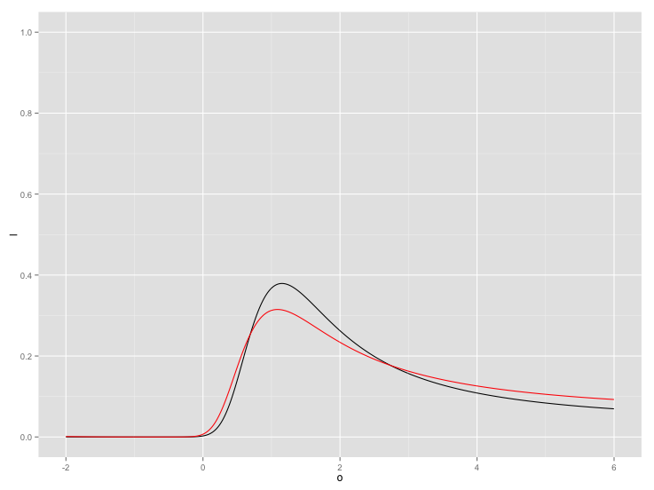

```r
# Libraries
library(ggplot2)
library(plyr)
library(metafor)

# Data
setwd('~/janus')
data <- read.csv('data/storer_1979.csv', sep='\t')

# Helpers
ggsave_for_ppt <- function(...) suppressWarnings(ggsave(...,
                                dpi=100,
                                width=10.24,
                                height=7.68,
                                units='in'))

model_10B4 <- function(data, o){
    glm(
        I(1/age) ~ I(dose + o*dose^2 / (fractions)),
        data=data,
        weights=n
    )
}
model_meta <- function(data, o){
    data$curved_dose <- with(data,
        dose + o*dose^2 / (fractions)
    )
    rma(
        1/age,
        (1/age - 1/(age + sd))^2,
        mods = cbind(curved_dose),
        data = data,
        method='ML'
    )
}

normalize_likelihood <- function(l, delta){
    l <- l - max(l)
    l <- exp(l)
    l <- l / sum(l)
    l <- l / delta

    l
}

# Constants
threshold = 1.5001

# Clean
data$fractions <- 1
data$fractions[data$rate < 0.1] <- Inf

# Define Acute
chronic <- data$rate < 0.1
data$type <- 'A'
data$type[chronic] <- 'C'

# Subset
data$modeled_in_10B4 <- with(data,
    dose < threshold &
    strain == 'RFM'  &
    sex == 'F' # &
    # rate != 0.4
)
data$in_my_analysis <- data$type == 'A'

# Model
low = -2
high = 6
delta = .01   # Reduce to increase resolution
o_range = (low/delta):(high/delta) * delta

get_likelihoods <- function(
    o_range,
    modeling_function=model_10B4,
    d=data[data$modeled_in_10B4,]
){
    r <- ldply(o_range, function(o){
        m <- modeling_function(d, o)
        l = logLik(m)

        data.frame(o, l)
    })

    r$l <- normalize_likelihood(r$l, delta)

    r
}


beir_r <- get_likelihoods(o_range)
my_r <- get_likelihoods(o_range, model_meta)


# Reproduce 10B4
# http://www.nap.edu/openbook.php?record_id=11340&page=258
ggplot(beir_r, aes(o, l)) +
    geom_path() +
    geom_path(data=my_r, color='red') +
    scale_y_continuous(breaks = c(0:5)/5, limits=c(0,1))
```

```r
ggsave_for_ppt('beir_10B4_meta_reression.png')
```

#### Results

It could be that the shoulder is very narrow, though this would be surprising given what we know about tissue level effects.

It could also be that there is some systematic bias between chronic and high dose experiments. For instance the high dose rate was even higher than the experimenters thought that it was.

More reason for meta-analysis.

^ back to table of contents

# Meta-regression on all data

*Last update: June 2013*

Show graphs like Storer 1979 10B3 but for all data using random effects meta-regression.

```r
# Libraries
library(ggplot2)
library(plyr)
library(metafor)

# Data
setwd("~/janus")
source("scripts/util/util.R")
data <- readRDS("data/ddref.rds")
```

#### Modeling functions

Specify modeling functions.

`model_10B3` will fit a linear quadratic model exactly as in the BEIR VII report, without accounting for within or between group error.

```r
model_10B3 <- function(data) {
    glm(I(1/age) ~ dose * cluster + I(dose^2/fractions) * cluster, data = data,
        weights = n)
}
```

`model_meta` will fit an identical model except that within group and between group error will be accounted for.

```r
model_meta <- function(data){
  data$a <- data$dose
  data$B <- with(data, dose^2 / (fractions))

  rma(
    yi,
    vi,
    mods = ~ a*cluster + B*cluster -a -B -1,
    data = data,
    method="ML"
  )
}


# Mean Lifespans
aggregate <- ddply(data, .(cluster, group_id, sex), function(df){
    u <- function(x) paste(unique(x), collapse=' ')
    dont_aggregate <- c('lifespan', 'id', 'X', 'n')
    n <- nrow(df)
    data.frame(
        llply(df[,!names(df) %in% dont_aggregate], u),
        age=mean(df$lifespan),
        sd=sd(df$lifespan)/n^0.5,
        n=nrow(df)
    )
})

# Prepare for Meta
aggregate$yi <- with(aggregate, 1/age)
aggregate$vi <- with(aggregate, (1/age - 1/(age + sd))^2)

# Restore Sanity
numerics <- names(data)[laply(data, is.numeric)]
for(n in numerics) {
    if(n %in% names(aggregate)){
        aggregate[,n] <- as.numeric(as.character(aggregate[,n]))
    }
}

# Model
m <- model_meta(aggregate)
```

```
## Error: Model matrix not of full rank. Cannot fit model.
```

```r
c <- coefficients(m)
aggregate <- aggregate %.%
  mutate(i=c[paste0('cluster', cluster)],
         a=c[paste0('a:cluster', cluster)],
         B=c[paste0('cluster', cluster, ':B')],
         tau2=m$tau2)
aggregate$p_my_analysis <- predict(m)$pred
```

```
## Error: replacement has 9 rows, data has 95
```

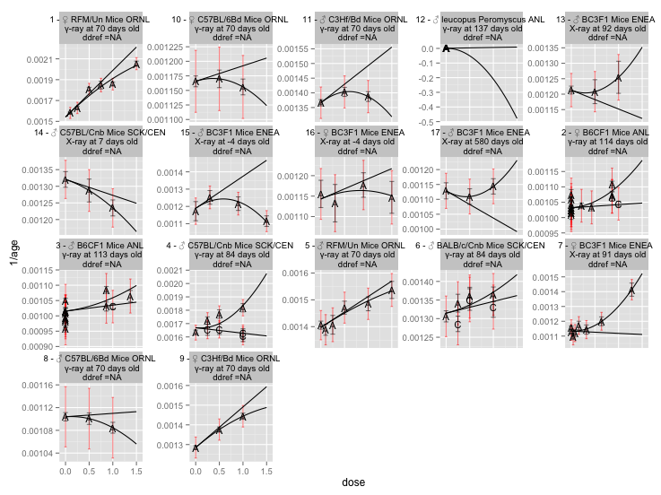

```r
aggregate$p_10B3 <- predict(model_10B3(aggregate))

# Project
# Add projections across the entire range (0-1.5 Gy) for
# acute and protracted exposures.  This will create nicer
# graphs.
doses = seq(from=0, to=1.5, by=.1)
coefficients = unique(aggregate[,c('i', 'a', 'B', 'cluster')])
projections = ddply(coefficients, .(cluster), function(df){
  acute <- with(df, cbind(data.frame(
    dose = doses,
    type = 'A',
    fractions = 1,
    p_my_analysis = i + a * doses + B * doses^2
  ), df))

  chronic <- with(df, cbind(data.frame(
    dose = doses,
    type = 'C',
    fractions = 1000,
    p_my_analysis = i + a * doses
  ), df))

  rbind(acute, chronic)
})
projections$p_10B3 <- predict(model_10B3(aggregate),
                              newdata=projections)

# Show
g <- aggregate
f <- function(x) round(x, 2)
g$cluster <- with(g, paste0(
    cluster, '\n',
    #'a=', f(a),
    #' B=', f(B),
    ' ddref =', f((a + B) / a)
))
projections$cluster <- projections$cluster
projections$cluster <- with(projections, paste0(
    cluster, '\n',
    #'a=', f(a),
    #' B=', f(B),
    ' ddref =', f((a + B) / a)
))

ggplot(g, aes(
    dose,
    1/age,
    label=type,
    group=type)) +
    geom_errorbar(aes(
        ymin=1/age + (vi + tau2)^0.5,
        ymax=1/age - (vi + tau2)^0.5
        ), alpha=0.5, width=.05, color='red') +
    geom_errorbar(aes(
        ymin=1/age + vi^0.5,
        ymax=1/age - vi^0.5
    ), alpha=0.5, width=.1) +
    geom_text(size=4) +
    geom_smooth(
        data = projections,
        aes(dose, p_10B3),
        method='lm',
        formula='y ~ x + I(x^2)',
        se=FALSE,
        color='black'
    ) +
    geom_smooth(
        data = projections,
        aes(dose, p_my_analysis),
        method='lm',
        formula='y ~ x + I(x^2)',
        se=FALSE,
        color='red'
    ) +
    facet_wrap(~ cluster, scales="free_y")
```

```r
ggsave_for_ppt('meta_regression.png')
```

^ back to table of contents

# Meta Regression profiles on all data

*Last update: June 2013*

Show graphs like Storer 1979 10B4 but for all data using the random effects meta regression.

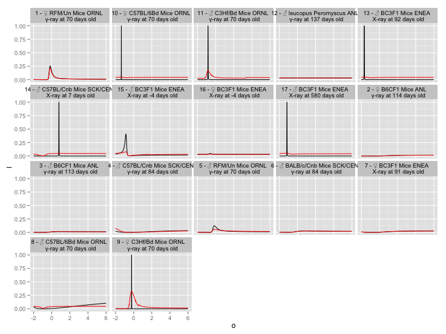

```r
# Libraries
library(ggplot2)
library(plyr)
library(metafor)

# Data
setwd("~/janus")
data <- readRDS("data/ddref.rds")

# Helpers
ggsave_for_ppt <- function(...) suppressWarnings(ggsave(..., dpi = 100, width = 10.24,
    height = 7.68, units = "in"))

model_10B4 <- function(data, o) {
    glm(I(1/age) ~ I(dose + o * dose^2/(fractions)), data = data, weights = n)
}
model_meta <- function(data, o) {
    data$curved_dose <- with(data, dose + o * dose^2/(fractions))
    rma(yi, vi, mods = cbind(curved_dose), data = data, method = "ML")
}
normalize_likelihood <- function(l, delta) {
    l <- l - max(l)
    l <- exp(l)
    l <- l/sum(l)
    l <- l/delta

    l
}

# Define Acute
chronic <- data$fractions > 1
data$type <- "A"
data$type[chronic] <- "C"

# Mean Lifespans
aggregate <- ddply(data, .(cluster, group_id, sex), function(df) {
    u <- function(x) paste(unique(x), collapse = " ")
    dont_aggregate <- c("lifespan", "id", "X", "n")
    n <- nrow(df)
    data.frame(llply(df[, !names(df) %in% dont_aggregate], u), age = mean(df$lifespan),
        sd = sd(df$lifespan)/n^0.5, n = nrow(df))
})

# Prepare for Meta
aggregate$yi <- with(aggregate, 1/age)
aggregate$vi <- with(aggregate, (1/age - 1/(age + sd))^2)

# Restore Sanity
numerics <- names(data)[laply(data, is.numeric)]
for (n in numerics) {
    if (n %in% names(aggregate)) {
        aggregate[, n] <- as.numeric(as.character(aggregate[, n]))
    }
}

# Model
low = -2
high = 6
delta = 0.01  # Reduce to increase resolution
o_range = (low/delta):(high/delta) * delta

# Model
aggregate <- ldply(o_range, function(o) {
    ddply(aggregate, .(cluster, sex), function(df) {

        # BEIR
        m <- model_10B4(df, o)
        df$l_10B4 <- logLik(m)

        # Random Effects
        m <- model_meta(df, o)
        df$l_meta <- logLik(m)

        df$o <- o
        df
    })
})

# Summarize Effect
get_summary_effect <- function(o, l) {
    aggregate <- data.frame(o, l)
    summary <- ddply(aggregate, .(o), function(df) {
        sum(df$l, na.rm = TRUE)
    })
    names(summary) <- c("o", "l")

    with(summary, data.frame(o, l))
}

summary_10B4 <- with(aggregate, get_summary_effect(o, l_10B4))
summary_meta <- with(aggregate, get_summary_effect(o, l_meta))
summary <- data.frame(o <- summary_10B4$o, l_10B4 <- normalize_likelihood(summary_10B4$l,
    delta), l_meta <- normalize_likelihood(summary_meta$l, delta))

# Normalize
aggregate <- ddply(aggregate, .(cluster, sex), function(df) {
    df$l_10B4 <- normalize_likelihood(df$l_10B4, delta)
    df$l_meta <- normalize_likelihood(df$l_meta, delta)
    df
})


# Show As in 10B4 http://www.nap.edu/openbook.php?record_id=11340&page=257
a <- aggregate

show <- function(g) {
    g$cluster <- as.factor(as.character(g$cluster))
    g$l_10B4 <- pmin(g$l_10B4, 1)
    g$l_meta <- pmin(g$l_meta, 1)
    suppressWarnings(print(ggplot(g, aes(o, l)) + geom_path(aes(o, l_10B4),
        color = "black") + geom_path(aes(o, l_meta), color = "red") + ylim(0,
        1) + facet_wrap(~cluster)))
}

g <- a
show(g)
```

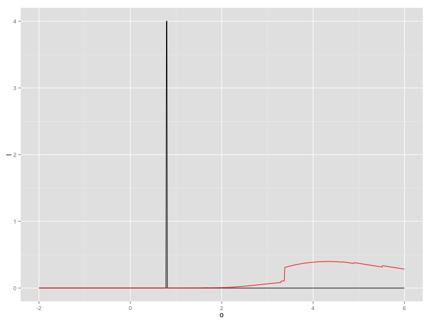

```r
ggsave_for_ppt("meta_regression_profile.png")

summary$l_10B4 <- pmin(4, summary$l_10B4)
summary$l_meta <- pmin(4, summary$l_meta)
ggplot(summary, aes(o, l)) + geom_path(aes(o, l_10B4), color = "black") + geom_path(aes(o,
    l_meta), color = "red") + ylim(0, 4)
```

```r
ggsave_for_ppt("meta_regression_summary_effect.png")
```

#### Results

We still seem to have biased likelihood estimates, but things are improving a bit…

^ back to table of contents